# Datos Hidrológicos

Yustin Leiva

23/5/2021

# **Proceso para cargar los datos del archivo csv al Rstudio**

### En este flujo de trabajo se va a utilizar los datos de el río Banano y el río Estrella

### El primer paso para este flujo de trabajo es crear un nuevo archivo en el entorno de R studio, el cual vamos a guardar en una carpeta en donde poseamos el archivo que en este caso lleva el nombre **FDC.csv**.

Para leer el archivo local que se posee se utiliza el comando:

```r
inp <- read.csv("FDC.csv",na.strings="")
head(inp)
```

```
##      Tiempo Pandora.mm..637km2. Banano.mm..90km2.
## 1 6/22/1973                7.46             21.02
## 2 6/23/1973                6.17             14.78
## 3 6/24/1973                6.32             27.65
## 4 6/25/1973                7.80             19.68
## 5 6/26/1973                7.72             15.17
## 6 6/27/1973                7.83             23.14
```

```r
dim(inp)
```

```
## [1] 3845    3
```

### La mejor forma de comprobar si el archivo posee celdas **“na”** que son celdas vacías, es mediante la siguiente funcion:

En caso de que posea celdas vacías se puede eliminar con: *newinp <- na.ommit(inp)*

```r
inp[!complete.cases(inp),]
```

```
## [1] Tiempo              Pandora.mm..637km2. Banano.mm..90km2.
## <0 rows> (or 0-length row.names)
```

# **Creación de gráficos**

### Utilizando la funcion **plot** se puede hacer un gráfico rapido, en este caso la variable del 2 se utiliza para identificar al río estrella, el **type=l** es para que el grafico se manifieste en forma de linea y **col** nos permite darle el color.

### La función **lines** se utiliza para agregar otra variable en este caso el 3, como rio banano.

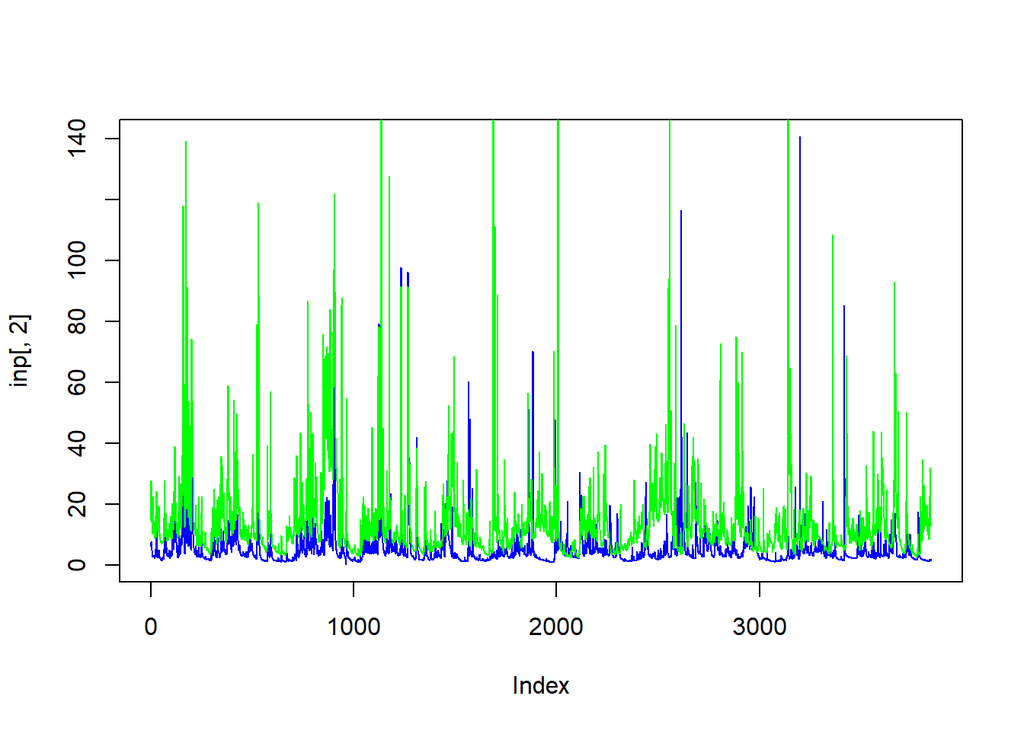

```r
plot(inp[,2], type="l", col="blue")
lines(inp[,3], col="green")
```

### De la siguiente manera se puede obtener el mínimo y el máximo de los datos:

```r
summary(inp[,2:3])
```

```
##  Pandora.mm..637km2. Banano.mm..90km2.
##  Min.   :  0.180     Min.   :  2.43
##  1st Qu.:  2.390     1st Qu.:  6.88
##  Median :  3.590     Median : 10.18
##  Mean   :  5.459     Mean   : 14.28
##  3rd Qu.:  5.900     3rd Qu.: 15.46
##  Max.   :140.650     Max.   :384.00
```

# **Visualización de un histograma**

### Para visualizar un histograma es necesario utilizar la función **hist**, como se muestra a continuación:

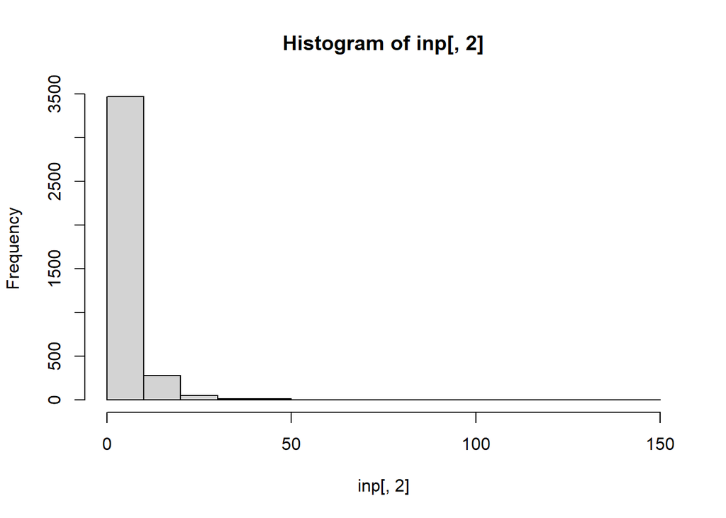

```r
hist(inp[,2])
```

Histograma del Río Estrella

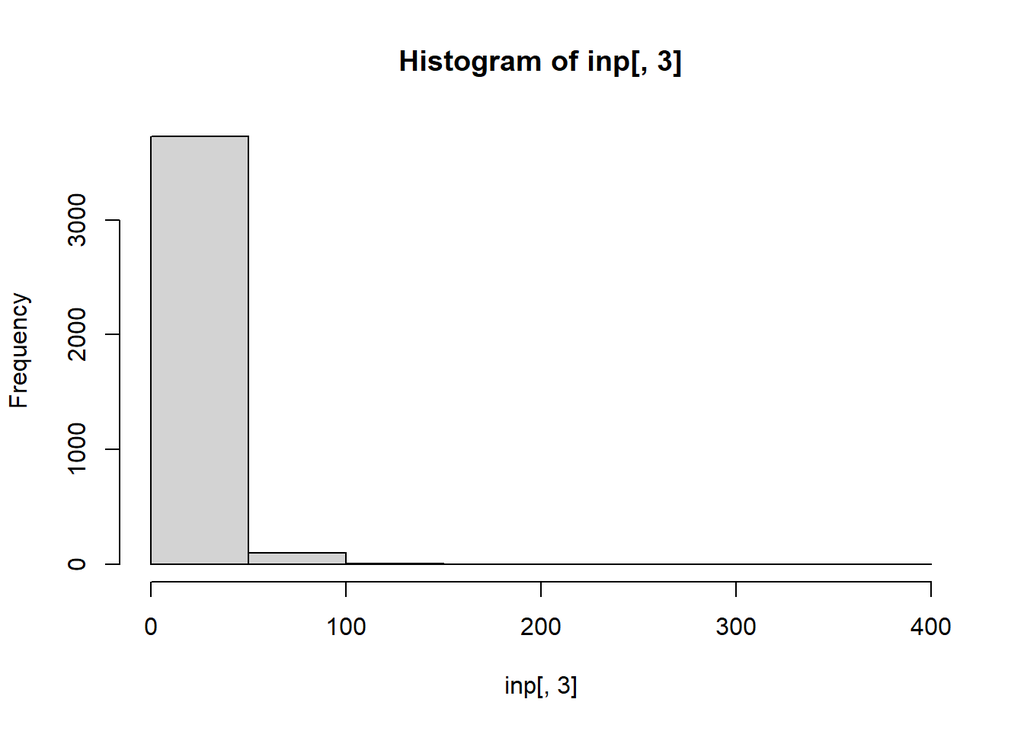

```r
hist(inp[,3])
```

Histograma del Río Banano

# **Nombrar las columnas del archivo**

### Para nombrar las columnas se puede utilizar la funcion **names**, en este caso el 1 es la fecha, el 2 es el rio Estrella y el 3 el rio Banano.

### La funcion **attach** en este caso se utiliza para hacer referencia al inp donde se encuentran en los archivos.

### Como se aprecia en el ultimo gráfico se cambió el 2, por el nombre que se le asignó.

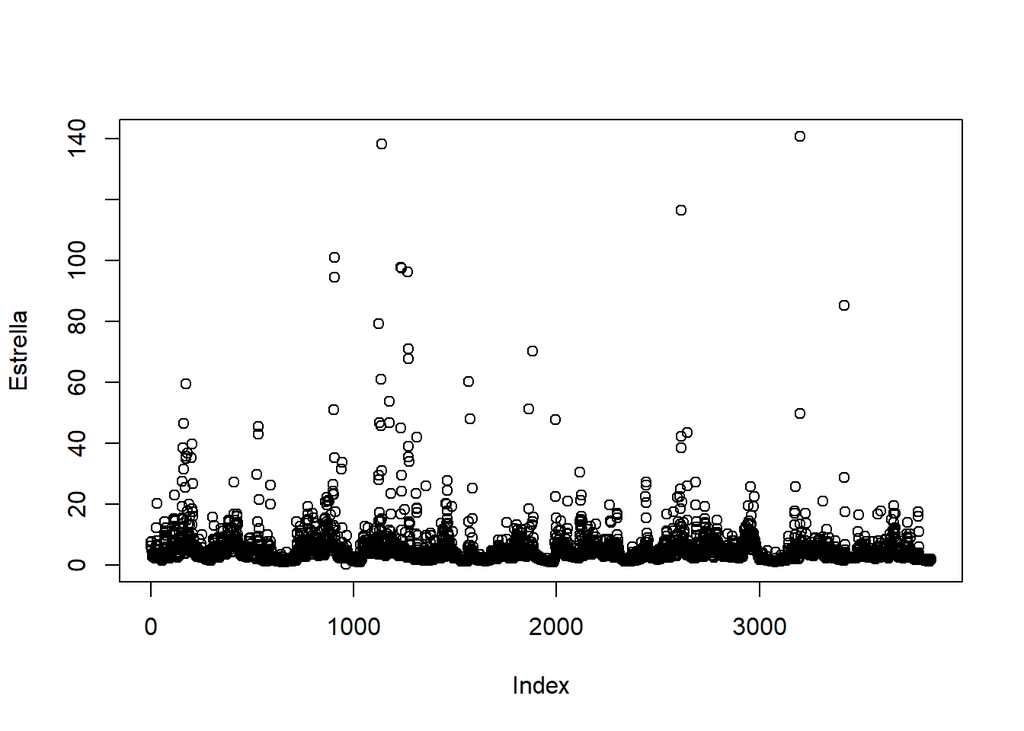

```r
names(inp) <- c("fecha", "Estrella", "Banano")
attach(inp)
plot(Estrella)
```

# **Definiendo formato de fecha**

```r
Tempdate <- strptime(inp[,1], format="%d/%m/%Y")
```

# **Obteniendo datos de una fecha especifica**

### Mediante el comando **tapply** se puede obtener el flujo del caudal del río Estrella y el río Banano entre los años 1973 a 1983.

Ambos resultados se pueden exportar a un archivo mediante la función **write**

```r
MAQ_Estrella <- tapply(Estrella, format(Tempdate, format="%Y"),FUN=sum)
MAQ_Banano <- tapply(Banano, format(Tempdate, format="%Y"),FUN=sum)
write.csv(rbind(MAQ_Estrella,MAQ_Banano), file="MAQ.csv")
```

## Gráfico de comparación entre el Río Banano y el Río Estrella

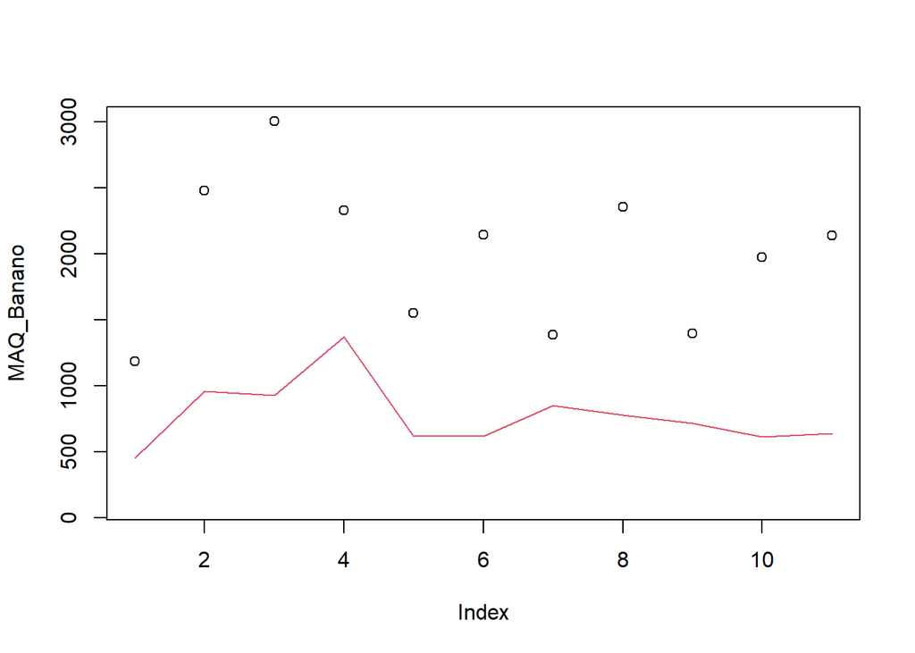

```r
plot(MAQ_Banano, ylim=c(100,3000))
lines(MAQ_Estrella, col=2)
```

```r
MMQ_Banano <- tapply(Banano, format(Tempdate, format="%m"),FUN=sum)
MMQ_Estrella <- tapply(Estrella, format(Tempdate, format="%m"),FUN=sum)
```

# **Análisis de coorrelación**

### Usamos la funcion de corinp, luego utilizamos cor para definir el metodo que se va a utilizar, los cuales son **“person”** **“kendall”** **“spearman”.**

### En este caso se utilizara el de spearman.

```r
corinp <- cor(inp[,2:3], method= "spearman")
```

```r
inp.lm <- lm(inp[,2] ~ inp[,3], data=inp)
summary(inp.lm)
```

```
##
## Call:
## lm(formula = inp[, 2] ~ inp[, 3], data = inp)
##
## Residuals:
##     Min      1Q  Median      3Q     Max
## -71.297  -2.267  -1.155   0.774 135.889
##
## Coefficients:
##             Estimate Std. Error t value Pr(>|t|)
## (Intercept)  2.70503    0.15174   17.83   <2e-16 ***
## inp[, 3]     0.19290    0.00707   27.28   <2e-16 ***
## ---
## Signif. codes:  0 '***' 0.001 '**' 0.01 '*' 0.05 '.' 0.1 ' ' 1
##
## Residual standard error: 7.025 on 3843 degrees of freedom
## Multiple R-squared:  0.1623, Adjusted R-squared:  0.162
## F-statistic: 744.4 on 1 and 3843 DF,  p-value: < 2.2e-16
```

Visualizaremos los gráficos con plot.

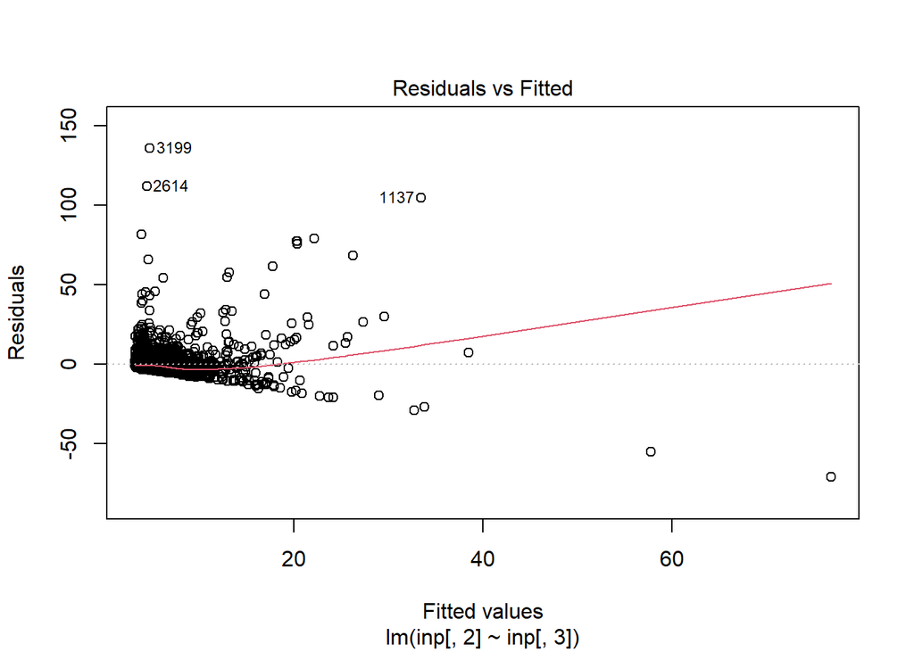

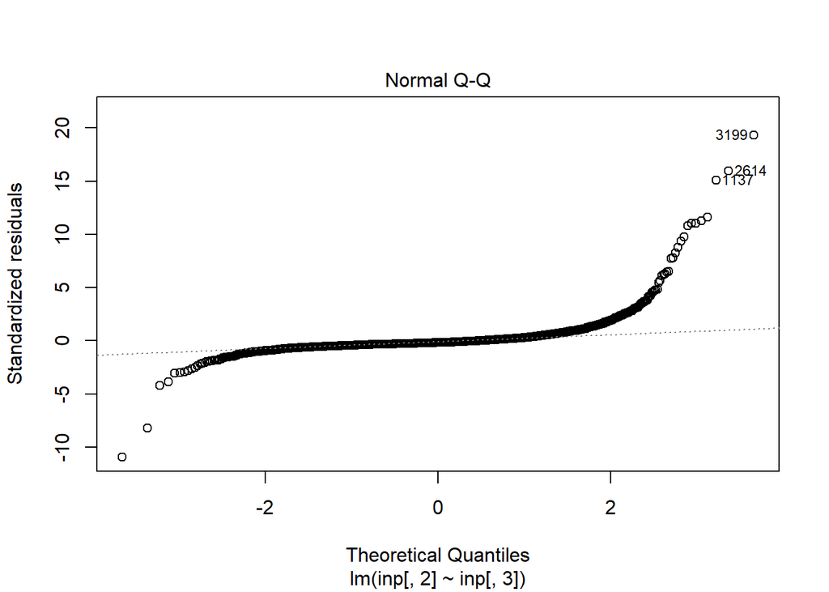

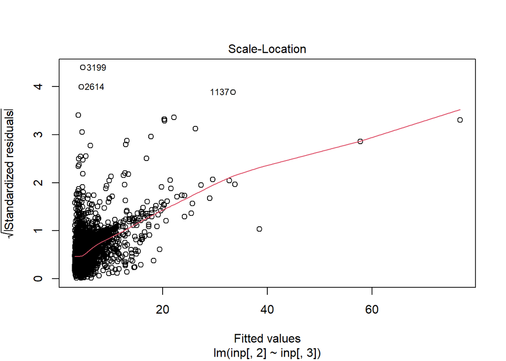

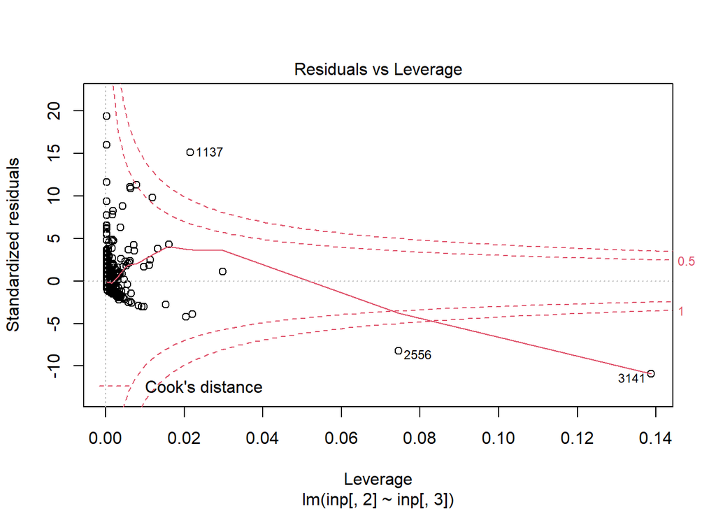

```r
plot(inp.lm)
```